# caseStudy1

Walter

January 11, 2020

The purpose of ths analysis is to determine which geographic regions are underserved in a beer company. Then, we determine which beer styles to sell to each region.

Load Data and Libraries

```r
beer=read.csv(file.choose())
breweries=read.csv(file.choose())
cities=read.csv(file.choose())
suppressPackageStartupMessages(
  {library(dplyr)
  library(grid)
  library(ggplot2)
  library(tidyr)
  library(maps)
  library(usmap)
  library(stringr)
  library(class)
  library(caret)
  library(Hmisc)
  library(gridExtra)
  library(naniar)}

)
```

INNER JOIN the brewery data with beer data using brewery ID.

```r
beerBrew=merge(beer,breweries,by.x="Brewery_id",by.y="Brew_ID")
```

# DETERMINING WHICH STATES DO NOT HAVE ENOUGH BEER

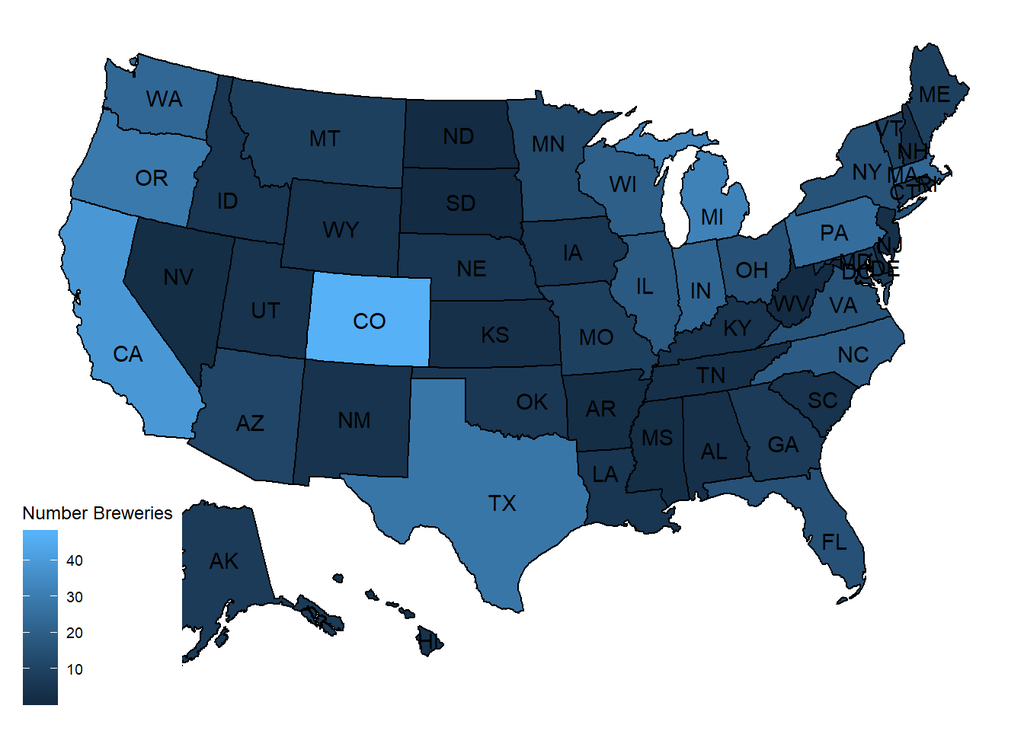

```r
stateCoords=us_map()
# Remove Leading Spaces from State Column of merged Beer Brew Data frame (prepare for join)
# Summarise Each State's Number of Breweries and Beers
stateBrewBeer= beerBrew %>% mutate(State=gsub(" ","",State)) %>% group_by(State) %>% summarise(brews=length(unique(Brewery_id)),beers=n())

#Join Brewery Beer Data with a dataframe containing state coordinates and population
statePopBrBe = merge(statepop,stateBrewBeer,all.x=TRUE,by.y="State",by.x="abbr")
statePopBrBe=statePopBrBe %>% mutate(brewCap=brews/pop_2015,beerCap=beers/pop_2015)

plot_usmap(data=statePopBrBe,values="brews",labels = TRUE)+scale_fill_continuous(name="Number Breweries")
```

8. Group 90 beer styles into 5 larger style buckets

```r
#Categorize the many styles into 5 groups


  beerBrew$StyleCat= case_when(
    grepl("(India Pale Ale|IPA)",beerBrew$Style) ~ "IPA",
    grepl( "Ale",beerBrew$Style) ~ "Ale",
    grepl("Lager",beerBrew$Style)~"Lager",
    grepl("Stout",beerBrew$Style)~"Stout",
    TRUE~"Other"
  )
```

# What percentage of sales does each beer category have?

1.Find the national percentages of each Style Category visually

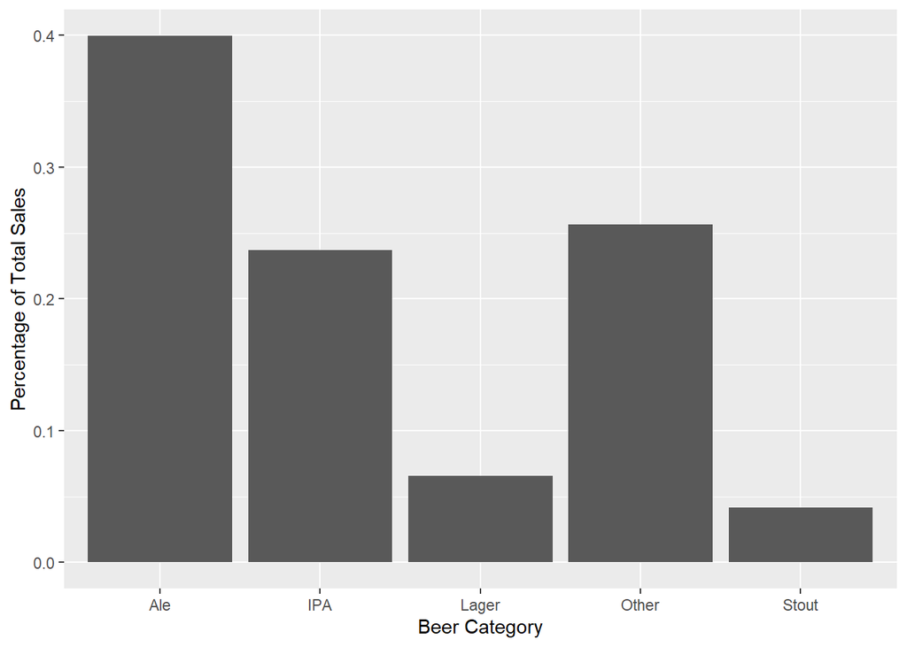

```r
#national percentage of styles
beerBrew %>% ggplot() + stat_summary(geom="bar",aes(StyleCat,Beer_ID),fun.y=function(x){
  length(unique(x))/length(unique(beerBrew$Beer_ID))
}) +xlab("Beer Category") +ylab("Percentage of Total Sales")
```

2. Table Format of national percentages

```r
nationalPct=beerBrew %>% group_by(StyleCat) %>% summarise(pct=n()/with(beerBrew,length(unique(Beer_ID))))
```

# Merge each brewery with the population of the city in which the brewery is located

```r
#remove the leading space in all States of beerBrew
beerBrew$State = with(beerBrew, gsub(as.character(State),pattern=" ",replacement = ""))
beerBrew$City=as.character(beerBrew$City)
cities$City= with(cities,as.character(City))
cities$State=with(cities,as.character(State))

#change State abbreviation to full name
States=map_data("state")
#create a Lookup table of state abbreviates and full state name to join
#beer data with city data
lookup = data.frame(abb = state.abb, State = state.name)
lookup$abb=as.character(lookup$abb)
lookup$State=as.character(lookup$State)
lookup=rbind(lookup,c("DC","district of columbia"))
# turn abbreviations to state names for beerBrew because cities has full names
beerBrew=merge(beerBrew,lookup,all.x=TRUE,by.x="State",by.y="abb")

#remove leading blanks in cities State field
cities$State = str_remove(cities$State,"^\\s")

# FINALLY
beerBrewCities = left_join(beerBrew, cities, by=c("City"="City","State.y"="State"))

beerBrewCities %>% select(Brewery_id,Name.x,City,X2018)%>%head()
```

```
##   Brewery_id                     Name.x      City   X2018
## 1        103            King Street IPA Anchorage 291,538
## 2        103                  Amber Ale Anchorage 291,538
## 3        494             Polar Pale Ale Anchorage 291,538
## 4        459          Sunken Island IPA  Soldotna    <NA>
## 5        103        King Street Pilsner Anchorage 291,538
## 6        459 Skilak Scottish Ale (2011)  Soldotna    <NA>
```

# How does each beer category’s sales vary from CITY TO CITY?

```r
  stylePctByState=beerBrew %>% group_by(State,City) %>%
  #find the total number of beers for each city without aggregating
  mutate(nBeers=length(unique(Beer_ID))) %>%
  ungroup()%>%
  #find the total number of beers for each city,style combination
  group_by(State,City,StyleCat) %>% summarise(nBeersPerStylePerCity=
                                                   length(unique(Beer_ID)),nBeers=
                                          mean(nBeers)) %>%
  #divide the number of Lagers in Minneapolis by the number of beers in minneapolis
  mutate(stylePct=nBeersPerStylePerCity/nBeers)%>% arrange(desc(stylePct)) %>%
  ungroup()%>%
  #find the average and standard deviation of all the cities' percentages of Lager,Ale,etc.
  group_by(StyleCat) %>%
  summarise(meanPct=mean(stylePct),sdPct=sd(stylePct))
stylePctByState
```

```
## # A tibble: 5 x 3
##   StyleCat meanPct sdPct
##   <chr>      <dbl> <dbl>
## 1 Ale        0.522 0.248
## 2 IPA        0.374 0.226
## 3 Lager      0.351 0.333
## 4 Other      0.401 0.236
## 5 Stout      0.194 0.173
```

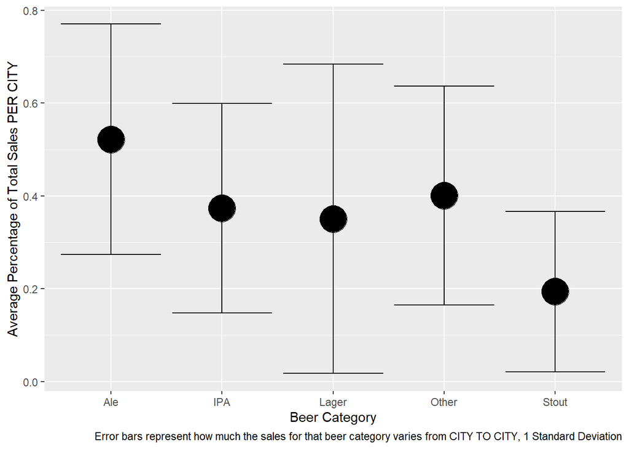

```r
stylePctByState %>% ggplot() + geom_point(aes(StyleCat,meanPct),size=10)+geom_errorbar(aes(
  x=StyleCat,ymin= meanPct-sdPct,ymax=meanPct+sdPct
))+xlab("Beer Category")+ylab("Average Percentage of Total Sales PER CITY")+labs(
  caption = "  Error bars represent how much the sales for that beer category varies from CITY TO CITY, 1 Standard Deviation"
)
```

# Find the cities with the fewest number of breweries per person.

```r
filterCity=targets0 %>%
  ungroup()%>%
  top_n(-25,brewPcap)
head(filterCity)
```

```
## # A tibble: 6 x 10
##   StyleCat State City  nBeersPerStyleP~ nBeers brewPcap  X2018 stylePct meanPct
##   <chr>    <chr> <chr>            <int>  <dbl>    <dbl>  <dbl>    <dbl>   <dbl>
## 1 Ale      CA    Sacr~                4      5  1.97e-6 508529    0.8     0.522
## 2 IPA      CA    Sacr~               NA     NA  1.97e-6 508529    0       0.374
## 3 Lager    CA    Sacr~                1      5  1.97e-6 508529    0.2     0.351
## 4 Other    CA    Sacr~               NA     NA  1.97e-6 508529    0       0.401
## 5 Stout    CA    Sacr~               NA     NA  1.97e-6 508529    0       0.194
## 6 Ale      MI    Detr~                1      6  1.49e-6 672662    0.167   0.522
## # ... with 1 more variable: sdPct <dbl>
```

# Which of the underserved cities are not selling enough Ale,IPA,Lager, Stout or Other category

# compared to national average?

From the chart below, we should prioritize in the following order: producing Ale in Kansas City and Detroit, “Other” in Sacremento, Kansas City and Nashville, IPA in Sacremento and Nashville,Lager in Memphis, Nashbille and Kansas City, Stout in all the 5 cities.

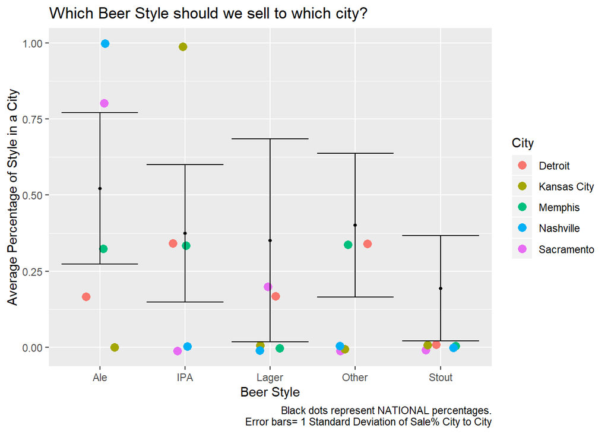

```r
ggplot(filterCity,aes(x=StyleCat)) + geom_point(aes(y=stylePct,col=City),size=3,position=position_jitter(width=0.2))+
   geom_point(aes(StyleCat,meanPct),size=1,data=stylePctByState)+geom_errorbar(aes(
  x=StyleCat,ymin= meanPct-sdPct,ymax=meanPct+sdPct
),data=stylePctByState)+ylab("Average Percentage of Style in a City")+
  xlab("Beer Style")+labs(title="Which Beer Style should we sell to which city?",
                          caption="Black dots represent NATIONAL percentages.
                          Error bars= 1 Standard Deviation of Sale% City to City")
```